# Tarea1-AlanGutierrez

AlanJosueGutierrez

2024-06-06

## Ejercicio 1

Se convocaron a estudiantes de enfermería y al público en general para registrarse y apoyar como voluntario en los puestos de vacunación contra covid. Si 7 de cada 10 voluntarios son estudiantes de enfermería:

1. Calcule la probabilidad de que se necesiten 40 voluntarios registrados para completar 20 estudiantes de enfermería.
2. Calcule la probabilidad de que se necesiten 30 voluntarios registrados para completar 20 estudiantes de enfermería.
3. Grafique la función de probabilidad (o densidad) utilizada.

Solución. 1.- Para este inciso se tiene una distribución binomial negativa con $r=20$ estudiantes de enfermería, los éxitos deseados entre los voluntarios. La variable $X$ representa los fracasos, es decir, las personas que no son estudiantes de enfermería, hasta que se obtienen los éxitos $r=20$ deseados.

$X =$ número de fracasos al que se obtiene el número $r$ de estudiantes de enfermería, entonces $X \sim BN(r=20,p=7/10)$

Queremos calcular $P[X=20]=f(20)$

```r
dnbinom(x=20, size=20, prob=0.7)
```

```
## [1] 0.001917572
```

2.- $X =$ número de fracasos $(10)$ al que se obtiene el número $r=20$ de estudiantes de enfermería, entonces $X \sim BN(r=20,p=7/10)$

Queremos calcular $P[X=10]=f(10)$

```r
dnbinom(x=10, size=20, prob=0.7)
```

```
## [1] 0.09437447
```

3. Graficamos la función de probabilidad

```r
x <- seq(0, 20, 1)
tabla.prob <- data.frame( x = x, probabilidad = dnbinom(x=x, size = 20, prob = 7/10))
tabla.prob
```

```
##     x probabilidad
## 1   0 0.0007979227
## 2   1 0.0047875360
## 3   2 0.0150807383
## 4   3 0.0331776243
## 5   4 0.0572314020
## 6   5 0.0824132188
## 7   6 0.1030165235
## 8   7 0.1147898405
## 9   8 0.1162247135
## 10  9 0.1084763993
## 11 10 0.0943744674
## 12 11 0.0772154733
## 13 12 0.0598419918
## 14 13 0.0441910093
## 15 14 0.0312493566
## 16 15 0.0212495625
## 17 16 0.0139450254
## 18 17 0.0088591926
## 19 18 0.0054631688
## 20 19 0.0032779013
## 21 20 0.0019175722
```

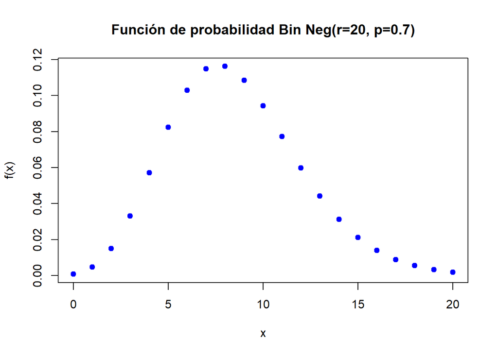

```r
plot( tabla.prob, main = "Función de probabilidad Bin Neg(r=20, p=0.7)", pch = 19, ylab = "f(x)", col ="blue")
```